# WA Pesticide Class Use Trends, 1992-2018

[figure not shown]

[figure not shown]

[figure not shown]

[figure not shown]

[figure not shown]

[figure not shown]

[figure not shown]

[figure not shown]

# Overview

### Total pesticide use, 2018

36,931,716 kg

### Top functional class, 2018

Fumigant: 20,653,386 kg

### Change since 1992

+226%

### Top crop group, 2018

Vegetables and fruit

### Overall annual use — all classified pesticides combined, 1992-2018

[interactive chart not shown]

### Annual use by functional class, 1992-2018

[interactive chart not shown]

### Annual use by chemical class, 1992-2018

[interactive chart not shown]

# Interactive Portal

### Explore by crop group

Functional class

Herbicide/algicide Fungicide Insecticide Plant Growth Regulator Acaricide Fumigant Insect Growth Regulator Other Bactericides Nematicides Insect Repellent Other

Crop group

Year

[interactive chart not shown]

### Underlying data (crop group view)

| Year | Functional class | Crop group | EPest-high (kg) |
| --- | --- | --- | --- |
| 1992 | Herbicide/algicide | Vegetables and fruit | 781817.9 |
| 1992 | Herbicide/algicide | Orchards and grapes | 278780.3 |
| 1992 | Herbicide/algicide | Wheat | 970274.2000000001 |
| 1992 | Herbicide/algicide | Pasture and hay | 468349.7 |
| 1992 | Herbicide/algicide | Corn | 185445.4 |
| 1992 | Herbicide/algicide | Alfalfa | 111932.5 |
| 1992 | Herbicide/algicide | Other crops | 280308.7 |
| 1992 | Fungicide | Vegetables and fruit | 204525.8 |
| 1992 | Fungicide | Orchards and grapes | 325346.9 |
| 1992 | Fungicide | Wheat | 26598.3 |

[output cut: 1226 more lines]

# Compound Explorer

### Explore by compound

Each line is one compound (color and hover label identify it). Narrow the Compound filter (or the Functional class/Chemical class filters) to a handful of active ingredients for the clearest view.

Functional class

Herbicide/algicide Fungicide Insecticide Plant Growth Regulator Acaricide Fumigant Insect Growth Regulator Other Bactericides Nematicides Insect Repellent Other

Chemical class

Compound

Year

[interactive chart not shown]

### Underlying data (compound view)

| Year | Functional class | Chemical class | Compound | EPest-high (kg) |
| --- | --- | --- | --- | --- |
| 1992 | Herbicide/algicide | Chlorophenoxy compound | 2,4-D | 487061.7 |
| 1992 | Herbicide/algicide | Chlorophenoxy compound | 2,4-DB | 8717.1 |
| 1992 | Herbicide/algicide | Chlorophenoxy compound | MCPA | 147820.5 |
| 1992 | Herbicide/algicide | Chlorophenoxy compound | MCPB | 78436 |
| 1992 | Herbicide/algicide | Dipyridyl compound | DIQUAT | 12955.8 |
| 1992 | Herbicide/algicide | Dipyridyl compound | PARAQUAT | 62999.7 |
| 1992 | Herbicide/algicide | Other | ALACHLOR | 113848.1 |
| 1992 | Herbicide/algicide | Other | BENFLURALIN | 122.7 |
| 1992 | Herbicide/algicide | Other | BENTAZONE | 50021 |
| 1992 | Herbicide/algicide | Other | BROMACIL | 218.7 |

[output cut: 5457 more lines]

# Static Plots

### Overall annual use by functional class

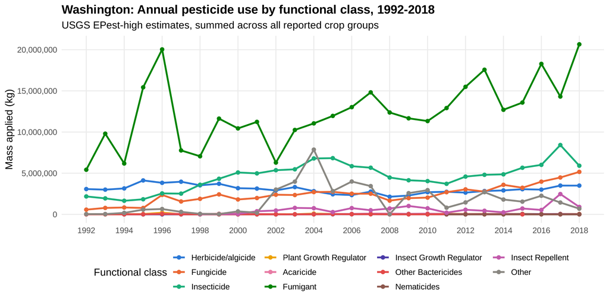

### Top 20 compounds by cumulative use, 1992-2018

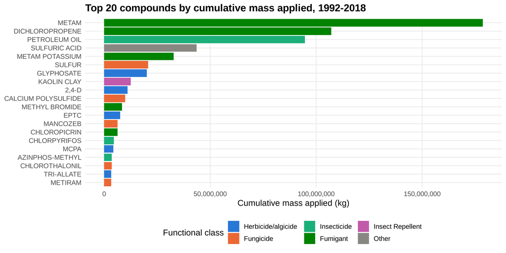

### Annual use of organophosphate & N-methyl carbamate pesticides

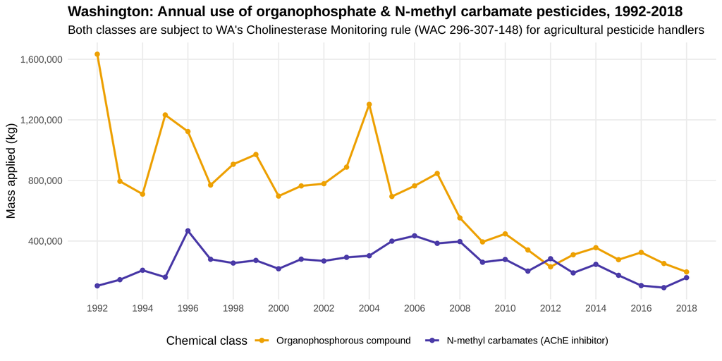

### Annual use of paraquat & diquat

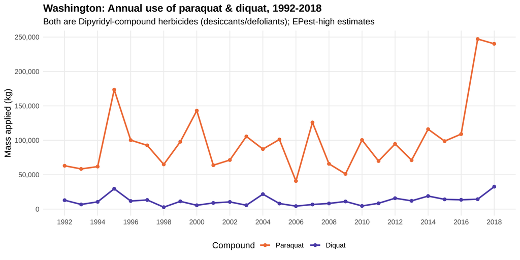

### Annual use of glyphosate

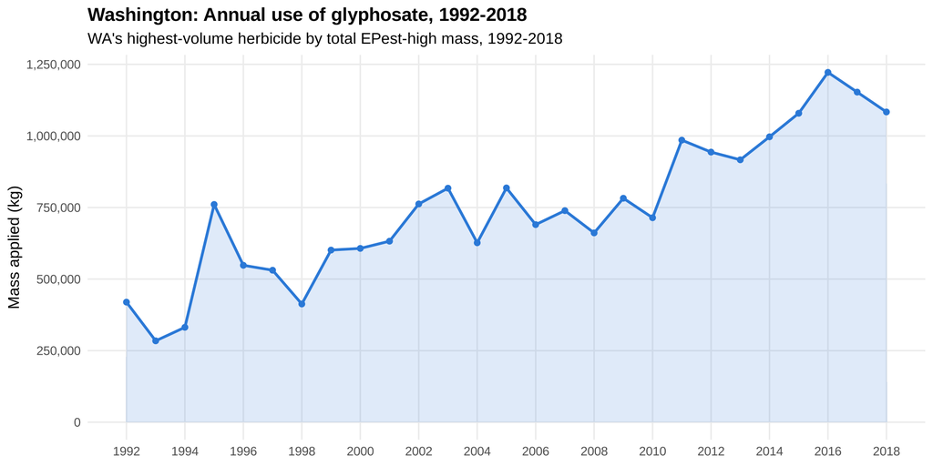

### Annual herbicide use by compound

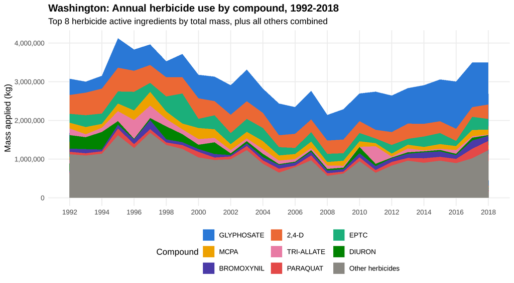

### Annual use by crop group

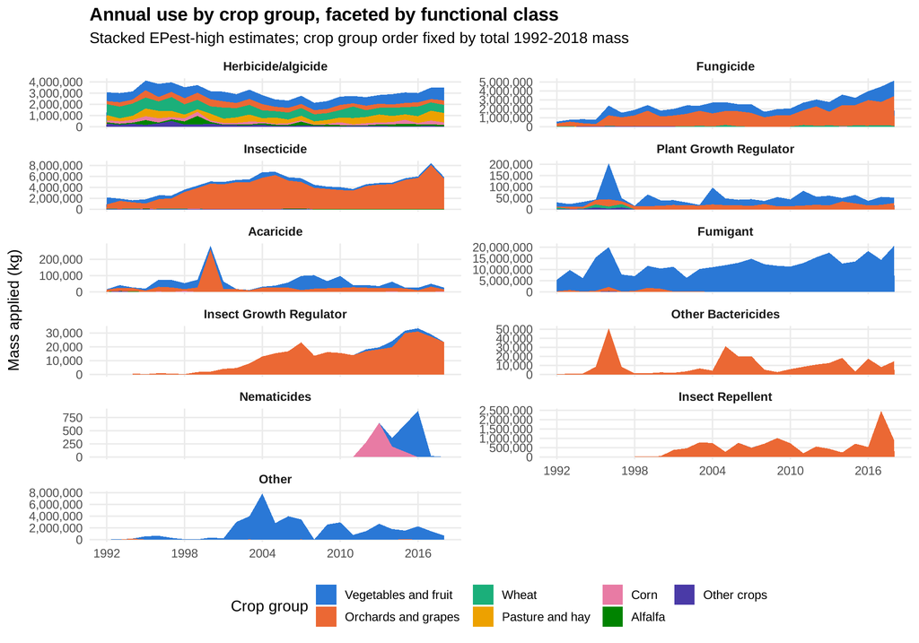

### Use intensity by year and crop group

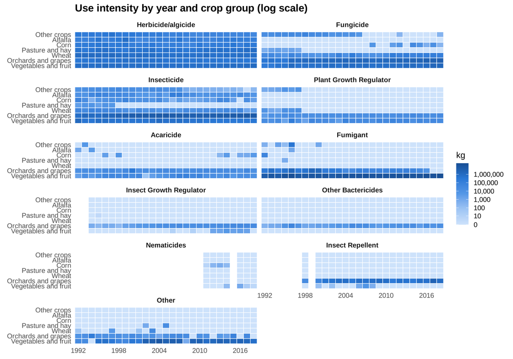

# Methodology & Data

### About this dashboard

Data source: USGS Pesticide National Synthesis Project, *Estimated Annual Agricultural Pesticide Use for Counties/States, by Crop Group* (1992-2019), file `HighEstimate_AgPestUsebyCropGroup92to19.txt`, downloaded from [ScienceBase item 6081ae7cd34e8564d6866222](https://www.sciencebase.gov/catalog/item/6081ae7cd34e8564d6866222). **This dashboard uses 1992-2018 only** — the file’s 2019 slice is a partial/preliminary release covering just 69 compounds nationwide (48 for Washington) versus roughly 400 (220+) in every other year. With the full classification in play, most compounds have no 2019 row at all, which would draw a sharp artificial drop at the end of every trend line if included. Re-run once a complete 2019 release is available.

This dashboard covers **Washington (FIPS 53)** only, filtered to the 402 compounds classified in `data/pesticide_classification.csv` (see the table below). Every compound reported for Washington in the source file is classified; none are dropped as “unclassifiable” — the classification’s own `Other` bucket is reserved for compounds outside the named families below (a few adjuvants, a molluscicide, a nitrogen stabilizer, and — for Chemical Class specifically — most modern chemistries not covered by the requested taxonomy; see below).

**Two grouping columns, verified compound-by-compound.** USGS’s own metadata for these data releases (Identification/Entity-Attribute Information sections) documents only the file’s structural columns (compound name, year, FIPS codes, crop-group amounts) — it does not publish a compound-level chemical/functional classification crosswalk. Both columns below were therefore built and checked one compound at a time against pesticide chemistry/mode-of-action references, not derived from a USGS-supplied table:

- **`FUNCTIONAL_CLASS`** — what the compound is *used for*: Insecticide, Herbicide/algicide, Fungicide, Fumigant, Rodenticide, Disinfectant/Broad Spectrum for Water Sanitation, Other Bactericides, Insect Repellent, Antifouling agent, Nematicides, Acaricides, Plant Growth Regulator (an addition beyond the base list, since ~19 compounds in this data are distinctly plant growth regulators rather than crop-protection products), or Other. Used for the headline charts on the Overview and Static Plots pages (only categories with recorded Washington use are plotted; Rodenticide, Disinfectant, and Antifouling have zero compounds in this agricultural-use dataset).
- **`CHEMICAL_CLASS`** — the compound’s structural/chemical family: Organochlorine compound, Organophosphorous compound, N-methyl carbamates (AChE inhibitor), Pyrethrins/Pyrethroids, Dipyridyl compound, Chlorophenoxy compound, Triazines, Thiocarbamates, Organo-metallic compound, Inorganic compounds, Microbial, Dithiocarbamates, or Other. This is a fairly classical taxonomy that predates several chemistries now in wide use (sulfonylurea and other ALS-inhibiting herbicides, DMI and SDHI and strobilurin fungicides, chloroacetanilide and dinitroaniline herbicides, neonicotinoid and diamide insecticides, and more) — those compounds correctly land in “Other” rather than being forced into an ill-fitting named family. 262 of 402 compounds (65%) fall into “Other” for this reason — but that share is by *compound count*, not mass; a handful of high-volume classes (dithiocarbamates, organochlorines, inorganics) account for most of the actual kg applied, which is why the Overview page’s “Annual use by chemical class” chart is still legible as a simultaneous multi-series color even though “Other” is the single largest named category. `CHEMICAL_CLASS` is also used for filtering on the Interactive Portal and Compound Explorer pages.

**Why organophosphates and N-methyl carbamates get their own chart.** The Static Plots page’s “Annual use of organophosphate & N-methyl carbamate pesticides” chart isolates just these two classes because both inhibit cholinesterase (an enzyme that regulates the neurotransmitter acetylcholine) by the same mechanism, and both are singled out together by Washington’s Cholinesterase Monitoring rule, [WAC 296-307-148](https://app.leg.wa.gov/wac/default.aspx?cite=296-307#:~:text=Part%20J%2D1,Cholinesterase%20Monitoring): employers of agricultural handlers who work 30+ hours in any 30-day period with toxicity category I or II compounds in either class must provide baseline and periodic cholinesterase blood testing, investigate significant drops, and meet several related recordkeeping and training requirements. (Washington L&I’s [state cost-reimbursement subsidy for this monitoring](https://www.lni.wa.gov/safety-health/_docs/ChEQA_2006.pdf) ended December 31, 2025 — the monitoring *requirement* itself did not. This dashboard’s data end in 2018, so the chart shows the historical use trend that the rule responds to, not any change since reimbursement ended.) Thiocarbamates and dithiocarbamates are chemically distinct (herbicide and fungicide families, respectively) and are not cholinesterase inhibitors, so they’re excluded from this chart even though “carbamate” appears in all three names.

Splitting these into two columns (rather than one column doing both jobs, as in this dashboard’s first version) directly fixes a real distortion: a handful of fumigants (metam, metam potassium, dichloropropene, chloropicrin) used to share a single “Fumigant” bucket that behaved like a chemical class, when fumigants are actually chemically diverse (a dithiocarbamate, in metam’s case) and are applied at far higher per-acre rates than herbicides or insecticides. That made raw-mass comparisons across the old classes misleading — Fumigant could dwarf Herbicide in total kg even though it covers only a handful of compounds. Functional Class still correctly shows fumigants’ true (large) total mass; Chemical Class now distributes that same mass into the compounds’ real chemistry instead of an artificial catch-all.

**EPest-high method.** Values are the *EPest-high* estimates described by Baker and Stone (2015) and Thelin and Stone (2013): where a Crop Reporting District (CRD) was surveyed but use of a given pesticide-by-crop combination was not reported, EPest-high treats that as missing data and imputes a rate from neighboring/regional CRDs, rather than assuming zero use (EPest-low). This dataset provides EPest-high only — EPest-low is not available in this crop-group product.

**Crop groups.** USGS aggregates crop-specific use into 10 groups: Corn, Soybeans, Wheat, Cotton, Vegetables & fruit, Rice, Orchards & grapes, Alfalfa, Pasture & hay, and Other crops. Groups with zero recorded Washington use across 1992-2018 for the classified compounds are omitted from the charts above.

**Caveats (per USGS):**

- Recent years use projected county/state crop acreage from the most recent Census of Agriculture at time of estimation and are revised as new Census data become available.
- Estimates are not appropriate for interpreting where/how much use occurs within a crop group at fine spatial detail; they summarize survey-based application rates aggregated to the state and crop-group level.
- A blank cell in the source file (no reported/estimated use for that compound-year-crop-group) is treated as zero in this dashboard.
- Classification is necessarily a simplification for compounds with legitimate dual uses — e.g. several compounds registered as both acaricides and general insecticides (abamectin, spiromesifen, spirotetramat) are assigned to whichever use is most commonly the compound’s primary registered purpose; fenoxycarb is chemically a carbamate ester but mechanistically an insect growth regulator (not an AChE inhibitor), so it’s classified by mechanism rather than by the “carbamate” name.

### Pesticide classification

402 compounds classified into 13 chemical classes and 11 functional classes; 380 of those were reported for Washington.

| Compound | Chemical class | Functional class |
| --- | --- | --- |
| FORMETANATE | N-methyl carbamates (AChE inhibitor) | Acaricide |
| FENBUTATIN OXIDE | Organo-metallic compound | Acaricide |
| DICOFOL | Organochlorine compound | Acaricide |
| DIENOCHLOR | Organochlorine compound | Acaricide |
| ACEQUINOCYL | Other | Acaricide |
| AMITRAZ | Other | Acaricide |
| BIFENAZATE | Other | Acaricide |
| CHINOMETHIONAT | Other | Acaricide |
| CLOFENTEZINE | Other | Acaricide |
| CYFLUMETOFEN | Other | Acaricide |

[output cut: 392 more lines]

````r
---
title: "WA Pesticide Class Use Trends, 1992-2018"
output:
  flexdashboard::flex_dashboard:
    orientation: rows
    vertical_layout: scroll
    theme: bootstrap
    source_code: embed
---

```{r setup, include=FALSE}
knitr::opts_chunk$set(echo = FALSE, warning = FALSE, message = FALSE)

required_pkgs <- c("flexdashboard", "dplyr", "tidyr", "readr", "forcats", "stringr",
                    "ggplot2", "plotly", "DT", "crosstalk", "scales", "knitr", "kableExtra")
invisible(lapply(required_pkgs, function(pkg) {
  library(pkg, character.only = TRUE)
}))

options(scipen = 999)
```

```{r constants}
# ---- Report scope -----------------------------------------------------
state_fips <- "53"
state_name <- "Washington"

crop_cols <- c("Corn", "Soybeans", "Wheat", "Cotton", "Vegetables_and_fruit",
                "Rice", "Orchards_and_grapes", "Alfalfa", "Pasture_and_hay",
                "Other_crops")

# ---- Palette (validated categorical order; see dataviz skill) ---------
cat_hex <- c("#2a78d6", "#eb6834", "#1baf7a", "#eda100",
              "#e87ba4", "#008300", "#4a3aa7", "#e34948",
              "#8c564b", "#c25aab", "#5b6b8c", "#b8860b")
muted_grey <- "#898781"

# FUNCTIONAL_CLASS is the broad, use-based grouping (what a compound is used
# for: Insecticide, Herbicide/algicide, Fungicide, Fumigant, ...) used for
# headline charts (fixed categorical color per class, "Other" folded to
# neutral grey). CHEMICAL_CLASS is the structural/chemical-family grouping
# (Organophosphorous compound, Pyrethrins/Pyrethroids, Triazines, ...) used
# for filtering/drilldown, not as a simultaneous multi-series color
# encoding -- most compounds' chemistry falls outside this taxonomy's named
# families and lands in "Other", so it isn't tractable as a chart color
# either. See the Methodology page for how each was assigned.
functional_levels <- c("Herbicide/algicide", "Fungicide", "Insecticide",
                        "Plant Growth Regulator", "Acaricide", "Fumigant",
                        "Insect Growth Regulator", "Other Bactericides",
                        "Nematicides", "Insect Repellent", "Other")
functional_colors <- setNames(c(cat_hex[1:10], muted_grey), functional_levels)

seq_blue <- c("#cde2fb", "#9ec5f4", "#5598e7", "#2a78d6", "#184f95")
```

```{r load-data}
raw <- read_delim(
  "../estimates/HighEstimate_AgPestUsebyCropGroup92to19.txt",
  delim = "\t",
  col_types = cols(
    State_FIPS_code = col_character(),
    State           = col_character(),
    Compound        = col_character(),
    Year            = col_integer(),
    Units           = col_character(),
    .default        = col_double()
  )
)

classification <- read_csv("../data/pesticide_classification.csv", col_types = cols())

# 2019 is excluded: this file's 2019 slice is a partial/preliminary release
# covering only 69 compounds nationwide (vs. ~400-410 in every other year).
# With the full pesticide-classification taxonomy in play (rather than the
# ~36-compound organophosphate/carbamate subset used previously, most of
# which happen to be in that partial release), including 2019 would draw a
# sharp artificial cliff at the end of every trend line. See the
# statewide-ranking chapter for the same exclusion.
wa <- raw %>%
  filter(State_FIPS_code == state_fips, Year <= 2018) %>%
  inner_join(classification, by = c("Compound" = "COMPOUND")) %>%
  mutate(FUNCTIONAL_CLASS = factor(FUNCTIONAL_CLASS, levels = functional_levels))

wa_long <- wa %>%
  pivot_longer(cols = all_of(crop_cols), names_to = "CROP_GROUP", values_to = "EPEST_HIGH_KG") %>%
  mutate(
    EPEST_HIGH_KG = replace_na(EPEST_HIGH_KG, 0),
    CROP_GROUP = str_replace_all(CROP_GROUP, "_", " ")
  ) %>%
  filter(!is.na(Year)) %>%
  select(Year, Compound, CHEMICAL_CLASS, FUNCTIONAL_CLASS, CROP_GROUP, EPEST_HIGH_KG)

# Fixed, stable crop-group order (by total 1992-2018 mass) so a given crop
# group keeps the same color everywhere in the dashboard. Crop groups with
# zero recorded use across the whole period are dropped rather than shown
# as empty series.
crop_group_totals <- wa_long %>%
  group_by(CROP_GROUP) %>%
  summarize(TOTAL_KG = sum(EPEST_HIGH_KG), .groups = "drop") %>%
  filter(TOTAL_KG > 0) %>%
  arrange(desc(TOTAL_KG))

crop_group_levels <- crop_group_totals$CROP_GROUP
crop_group_colors <- setNames(cat_hex[seq_along(crop_group_levels)], crop_group_levels)

wa_long <- wa_long %>%
  filter(CROP_GROUP %in% crop_group_levels) %>%
  mutate(CROP_GROUP = factor(CROP_GROUP, levels = crop_group_levels))

# Functional classes with zero recorded use are dropped from
# FUNCTIONAL_CLASS-faceted charts the same way crop groups are.
functional_totals <- wa_long %>%
  group_by(FUNCTIONAL_CLASS) %>%
  summarize(TOTAL_KG = sum(EPEST_HIGH_KG), .groups = "drop") %>%
  filter(TOTAL_KG > 0) %>%
  arrange(match(FUNCTIONAL_CLASS, functional_levels))
active_functional_classes <- as.character(functional_totals$FUNCTIONAL_CLASS)

# Same idea for CHEMICAL_CLASS, but ordered by mass (descending) rather
# than a fixed order -- unlike FUNCTIONAL_CLASS's 7-ish intuitive
# categories, there's no natural reading order for 13 chemical families,
# so ranking by total mass at least puts the most consequential classes
# first in the legend. "Other" always gets the neutral grey regardless of
# its rank, matching the FUNCTIONAL_CLASS convention.
chemical_totals <- wa_long %>%
  group_by(CHEMICAL_CLASS) %>%
  summarize(TOTAL_KG = sum(EPEST_HIGH_KG), .groups = "drop") %>%
  filter(TOTAL_KG > 0) %>%
  arrange(desc(TOTAL_KG))
active_chemical_classes <- as.character(chemical_totals$CHEMICAL_CLASS)
named_chemical_classes <- setdiff(active_chemical_classes, "Other")
chemical_colors <- setNames(cat_hex[seq_along(named_chemical_classes)], named_chemical_classes)
if ("Other" %in% active_chemical_classes) chemical_colors <- c(chemical_colors, Other = muted_grey)
chemical_colors <- chemical_colors[active_chemical_classes]

year_range <- range(wa_long$Year)
latest_year <- max(wa_long$Year)
first_year <- min(wa_long$Year)
````

````r
# ---- Pre-aggregated summaries used throughout the dashboard -----------
annual_by_functional <- wa_long %>%
  group_by(Year, FUNCTIONAL_CLASS) %>%
  summarize(EPEST_HIGH_KG = sum(EPEST_HIGH_KG), .groups = "drop")

annual_by_chemical <- wa_long %>%
  filter(CHEMICAL_CLASS %in% active_chemical_classes) %>%
  group_by(Year, CHEMICAL_CLASS) %>%
  summarize(EPEST_HIGH_KG = sum(EPEST_HIGH_KG), .groups = "drop") %>%
  mutate(CHEMICAL_CLASS = factor(CHEMICAL_CLASS, levels = active_chemical_classes))

annual_by_functional_crop <- wa_long %>%
  filter(FUNCTIONAL_CLASS %in% active_functional_classes) %>%
  group_by(Year, FUNCTIONAL_CLASS, CROP_GROUP) %>%
  summarize(EPEST_HIGH_KG = sum(EPEST_HIGH_KG), .groups = "drop") %>%
  mutate(FUNCTIONAL_CLASS = factor(FUNCTIONAL_CLASS, levels = active_functional_classes))

annual_by_compound <- wa_long %>%
  group_by(Year, FUNCTIONAL_CLASS, CHEMICAL_CLASS, Compound) %>%
  summarize(EPEST_HIGH_KG = sum(EPEST_HIGH_KG), .groups = "drop")

annual_overall <- wa_long %>%
  group_by(Year) %>%
  summarize(EPEST_HIGH_KG = sum(EPEST_HIGH_KG), .groups = "drop")
```

```{r overview-stats}
total_latest <- annual_overall %>% filter(Year == latest_year) %>% pull(EPEST_HIGH_KG)
total_first  <- annual_overall %>% filter(Year == first_year)  %>% pull(EPEST_HIGH_KG)
total_pct_change <- 100 * (total_latest - total_first) / total_first

top_functional_latest <- annual_by_functional %>%
  filter(Year == latest_year) %>%
  arrange(desc(EPEST_HIGH_KG)) %>%
  slice(1)

top_crop_latest <- annual_by_functional_crop %>%
  filter(Year == latest_year) %>%
  group_by(CROP_GROUP) %>%
  summarize(EPEST_HIGH_KG = sum(EPEST_HIGH_KG), .groups = "drop") %>%
  arrange(desc(EPEST_HIGH_KG)) %>%
  slice(1)
```

Overview
=======================================================================

Row {data-height=140}
-----------------------------------------------------------------------

### Total pesticide use, `r latest_year` {.value-box}

```{r}
valueBox(paste0(comma(round(total_latest)), " kg"),
         caption = paste0("All classified compounds, ", latest_year, " (EPest-high)"),
         icon = "fa-flask", color = cat_hex[1])
```

### Top functional class, `r latest_year` {.value-box}

```{r}
valueBox(paste0(as.character(top_functional_latest$FUNCTIONAL_CLASS), ": ", comma(round(top_functional_latest$EPEST_HIGH_KG)), " kg"),
         caption = paste0("Largest pesticide functional class by mass, ", latest_year),
         icon = "fa-layer-group", color = cat_hex[2])
```

### Change since `r first_year` {.value-box}

```{r}
valueBox(paste0(ifelse(total_pct_change >= 0, "+", ""), round(total_pct_change), "%"),
         caption = paste0("Total classified pesticide use, ", first_year, "-", latest_year),
         icon = ifelse(total_pct_change >= 0, "fa-arrow-up", "fa-arrow-down"),
         # Explicit hex, not the "warning" keyword: flexdashboard's default
         # theme pairs "warning" with white value-box text on a pale yellow
         # background, which is nearly unreadable (see dataviz skill's
         # status-palette contrast notes). cat_hex[2] keeps white-text
         # contrast on an increase; "success" already renders fine.
         color = ifelse(total_pct_change >= 0, cat_hex[2], "success"))
```

### Top crop group, `r latest_year` {.value-box}

```{r}
valueBox(as.character(top_crop_latest$CROP_GROUP),
         caption = paste0("Largest combined use across all classes, ", latest_year),
         icon = "fa-seedling", color = "primary")
```

Row {data-height=430}
-----------------------------------------------------------------------

### Overall annual use <e2><80><94> all classified pesticides combined, `r first_year`-`r latest_year`

```{r}
p <- plot_ly(annual_overall, x = ~Year, y = ~EPEST_HIGH_KG, type = "scatter", mode = "lines",
             fill = "tozeroy", fillcolor = "rgba(42,120,214,0.15)",
             line = list(color = cat_hex[1], width = 2),
             hovertemplate = "%{x}: %{y:,.0f} kg<extra></extra>") %>%
  layout(
    yaxis = list(title = "EPest-high estimate (kg)", rangemode = "tozero", tickformat = ","),
    xaxis = list(title = "Year", dtick = 2),
    hovermode = "x unified"
  )
p
```

Row {data-height=430}
-----------------------------------------------------------------------

### Annual use by functional class, `r first_year`-`r latest_year`

```{r}
plot_ly(annual_by_functional, x = ~Year, y = ~EPEST_HIGH_KG, color = ~FUNCTIONAL_CLASS,
        colors = functional_colors, type = "scatter", mode = "lines+markers",
        line = list(width = 2), marker = list(size = 5),
        hovertemplate = "%{x}: %{y:,.0f} kg<extra>%{fullData.name}</extra>") %>%
  layout(
    yaxis = list(title = "EPest-high estimate (kg)", rangemode = "tozero", tickformat = ","),
    xaxis = list(title = "Year", dtick = 2),
    legend = list(title = list(text = "Functional class"), orientation = "h", y = -0.2),
    hovermode = "x unified"
  )
```

Row {data-height=430}
-----------------------------------------------------------------------

### Annual use by chemical class, `r first_year`-`r latest_year`

```{r}
plot_ly(annual_by_chemical, x = ~Year, y = ~EPEST_HIGH_KG, color = ~CHEMICAL_CLASS,
        colors = chemical_colors, type = "scatter", mode = "lines+markers",
        line = list(width = 2), marker = list(size = 5),
        hovertemplate = "%{x}: %{y:,.0f} kg<extra>%{fullData.name}</extra>") %>%
  layout(
    yaxis = list(title = "EPest-high estimate (kg)", rangemode = "tozero", tickformat = ","),
    xaxis = list(title = "Year", dtick = 2),
    legend = list(title = list(text = "Chemical class"), orientation = "h", y = -0.3),
    hovermode = "x unified"
  )
```

Interactive Portal
=======================================================================

Row {data-height=700}
-----------------------------------------------------------------------

### Explore by crop group

Tip: lines are colored by crop group and dashed by functional class.
Chemical-class filtering (13 named families, most compounds falling
outside them into "Other") is on the Compound Explorer page instead <e2><80><94>
plotting crop-group trends split by chemical class at once would make the
lines and legend unreadable, so this view stops at functional class (11
categories).
````

````r
```{r portal-crop-setup}
# Grain matches exactly what's plotted (Year x Functional class x Crop
# group): unlike a compound-level chart, a crop-group line has no compound
# identity to split on, so if the shared data still had a chemical-class
# dimension underneath, multiple classes' values for the same
# year/crop-group would connect into one jagged, meaningless line.
# Aggregating away chemical class here (Compound Explorer covers that
# level) keeps every plotted line a true 1-row-per-year series regardless
# of which functional-class boxes are checked.
functional_crop_active <- wa_long %>%
  filter(FUNCTIONAL_CLASS %in% active_functional_classes) %>%
  group_by(FUNCTIONAL_CLASS, CROP_GROUP) %>%
  mutate(PAIR_TOTAL = sum(EPEST_HIGH_KG)) %>%
  ungroup() %>%
  filter(PAIR_TOTAL > 0) %>%
  group_by(Year, FUNCTIONAL_CLASS, CROP_GROUP) %>%
  summarize(EPEST_HIGH_KG = sum(EPEST_HIGH_KG), .groups = "drop")

crop_shared <- SharedData$new(functional_crop_active, ~paste(Year, FUNCTIONAL_CLASS, CROP_GROUP), group = "crop_portal")
```

```{r}
htmltools::div(
  style = "padding: 8px 8px 8px 22px;",
  bscols(
    widths = c(3, 9),
    list(
      filter_checkbox("func_crop", "Functional class", crop_shared, ~FUNCTIONAL_CLASS, inline = TRUE),
      filter_select("crop_sel", "Crop group", crop_shared, ~CROP_GROUP, multiple = TRUE),
      filter_slider("year_crop", "Year", crop_shared, ~Year, step = 1, sep = "", width = "100%")
    ),
    plot_ly(crop_shared, x = ~Year, y = ~EPEST_HIGH_KG, color = ~CROP_GROUP,
            colors = crop_group_colors, linetype = ~FUNCTIONAL_CLASS,
            type = "scatter", mode = "lines+markers", height = 600,
            line = list(width = 2), marker = list(size = 5),
            hovertemplate = "%{x}: %{y:,.0f} kg<extra>%{fullData.name}</extra>") %>%
      layout(
        yaxis = list(title = "EPest-high estimate (kg)", rangemode = "tozero", tickformat = ","),
        xaxis = list(title = "Year"),
        legend = list(title = list(text = "Crop group / functional class"), font = list(size = 9))
      )
  )
)
```

Row {data-height=400}
-----------------------------------------------------------------------

### Underlying data (crop group view)

```{r}
datatable(
  crop_shared,
  extensions = "Scroller",
  colnames = c("Year", "Functional class", "Crop group", "EPest-high (kg)"),
  options = list(deferRender = TRUE, scrollY = 260, scroller = TRUE, dom = "ftip"),
  rownames = FALSE
) %>%
  formatRound("EPEST_HIGH_KG", 0)
```

Compound Explorer
=======================================================================

Row {data-height=700}
-----------------------------------------------------------------------

### Explore by compound

Each line is one compound (color and hover label identify it). Narrow the
Compound filter (or the Functional class/Chemical class filters) to a
handful of active ingredients for the clearest view.

```{r portal-compound-setup}
compound_shared <- SharedData$new(annual_by_compound, ~paste(Year, FUNCTIONAL_CLASS, CHEMICAL_CLASS, Compound), group = "compound_portal")
```

```{r}
htmltools::div(
  style = "padding: 8px 8px 8px 22px;",
  bscols(
    widths = c(3, 9),
    list(
      filter_checkbox("func_cmp", "Functional class", compound_shared, ~FUNCTIONAL_CLASS, inline = TRUE),
      filter_select("class_cmp", "Chemical class", compound_shared, ~CHEMICAL_CLASS, multiple = TRUE),
      filter_select("compound_sel", "Compound", compound_shared, ~Compound, multiple = TRUE),
      filter_slider("year_cmp", "Year", compound_shared, ~Year, step = 1, sep = "", width = "100%")
    ),
    plot_ly(compound_shared, x = ~Year, y = ~EPEST_HIGH_KG, color = ~Compound,
            text = ~paste0(FUNCTIONAL_CLASS, " / ", CHEMICAL_CLASS), height = 600,
            type = "scatter", mode = "lines+markers",
            line = list(width = 1.5), marker = list(size = 4),
            hovertemplate = "%{fullData.name} (%{text}), %{x}: %{y:,.0f} kg<extra></extra>") %>%
      layout(
        yaxis = list(title = "EPest-high estimate (kg)", rangemode = "tozero", tickformat = ","),
        xaxis = list(title = "Year"),
        legend = list(title = list(text = "Compound"), font = list(size = 9))
      )
  )
)
```

Row {data-height=400}
-----------------------------------------------------------------------

### Underlying data (compound view)

```{r}
datatable(
  compound_shared,
  extensions = "Scroller",
  colnames = c("Year", "Functional class", "Chemical class", "Compound", "EPest-high (kg)"),
  options = list(deferRender = TRUE, scrollY = 260, scroller = TRUE, dom = "ftip"),
  rownames = FALSE
) %>%
  formatRound("EPEST_HIGH_KG", 0)
```

Static Plots
=======================================================================

Row {data-height=500}
-----------------------------------------------------------------------

### Overall annual use by functional class

```{r static-type-trend, fig.width=10, fig.height=5}
ggplot(annual_by_functional, aes(x = Year, y = EPEST_HIGH_KG, color = FUNCTIONAL_CLASS)) +
  geom_line(linewidth = 1) +
  geom_point(size = 1.8) +
  scale_color_manual(values = functional_colors, name = "Functional class") +
  scale_y_continuous(labels = comma) +
  scale_x_continuous(breaks = seq(first_year, latest_year, by = 2)) +
  labs(
    title = paste0(state_name, ": Annual pesticide use by functional class, ", first_year, "-", latest_year),
    subtitle = "USGS EPest-high estimates, summed across all reported crop groups",
    x = NULL, y = "Mass applied (kg)"
  ) +
  theme_minimal(base_size = 12) +
  theme(
    legend.position = "bottom",
    panel.grid.minor = element_blank(),
    plot.title = element_text(face = "bold")
  )
```

### Top 20 compounds by cumulative use, `r first_year`-`r latest_year`

```{r static-top-compounds, fig.width=10, fig.height=5}
top_compounds <- annual_by_compound %>%
  group_by(FUNCTIONAL_CLASS, CHEMICAL_CLASS, Compound) %>%
  summarize(TOTAL_KG = sum(EPEST_HIGH_KG), .groups = "drop") %>%
  arrange(desc(TOTAL_KG)) %>%
  slice(1:20) %>%
  mutate(Compound = fct_reorder(Compound, TOTAL_KG))
````

````r
ggplot(top_compounds, aes(x = Compound, y = TOTAL_KG, fill = FUNCTIONAL_CLASS)) +
  geom_col() +
  coord_flip() +
  scale_fill_manual(values = functional_colors, name = "Functional class") +
  scale_y_continuous(labels = comma) +
  labs(
    title = paste0("Top 20 compounds by cumulative mass applied, ", first_year, "-", latest_year),
    x = NULL, y = "Cumulative mass applied (kg)"
  ) +
  theme_minimal(base_size = 12) +
  theme(legend.position = "bottom", panel.grid.minor = element_blank(), plot.title = element_text(face = "bold"))
```

Row {data-height=500}
-----------------------------------------------------------------------

### Annual use of organophosphate & N-methyl carbamate pesticides

```{r static-cholinesterase-classes, fig.width=10, fig.height=5}
# WA's Cholinesterase Monitoring rule (WAC 296-307-148) covers agricultural
# handlers of toxicity category I/II organophosphate or N-methyl-carbamate
# pesticides specifically -- not thiocarbamates or dithiocarbamates, which
# are chemically distinct (herbicide/fungicide families) and aren't
# cholinesterase inhibitors.
cholinesterase_classes <- c("Organophosphorous compound", "N-methyl carbamates (AChE inhibitor)")

annual_cholinesterase <- annual_by_chemical %>%
  filter(CHEMICAL_CLASS %in% cholinesterase_classes) %>%
  mutate(CHEMICAL_CLASS = factor(CHEMICAL_CLASS, levels = cholinesterase_classes))

ggplot(annual_cholinesterase, aes(x = Year, y = EPEST_HIGH_KG, color = CHEMICAL_CLASS)) +
  geom_line(linewidth = 1) +
  geom_point(size = 1.8) +
  scale_color_manual(values = chemical_colors[cholinesterase_classes], name = "Chemical class") +
  scale_y_continuous(labels = comma) +
  scale_x_continuous(breaks = seq(first_year, latest_year, by = 2)) +
  labs(
    title = paste0(state_name, ": Annual use of organophosphate & N-methyl carbamate pesticides, ", first_year, "-", latest_year),
    subtitle = "Both classes are subject to WA's Cholinesterase Monitoring rule (WAC 296-307-148) for agricultural pesticide handlers",
    x = NULL, y = "Mass applied (kg)"
  ) +
  theme_minimal(base_size = 12) +
  theme(
    legend.position = "bottom",
    panel.grid.minor = element_blank(),
    plot.title = element_text(face = "bold")
  )
```

Row {data-height=500}
-----------------------------------------------------------------------

### Annual use of paraquat & diquat

```{r static-paraquat-diquat, fig.width=10, fig.height=5}
# Paraquat and diquat are both dipyridylium (bipyridyl) herbicides --
# chemically similar (CHEMICAL_CLASS "Dipyridyl compound" for both) and
# frequently discussed together, so plotted on one chart rather than
# split across the two individual-compound charts below.
bipyridyl_compounds <- c("PARAQUAT", "DIQUAT")

annual_bipyridyl <- annual_by_compound %>%
  filter(Compound %in% bipyridyl_compounds) %>%
  mutate(Compound = factor(Compound, levels = bipyridyl_compounds))

bipyridyl_colors <- setNames(cat_hex[c(2, 7)], bipyridyl_compounds)

ggplot(annual_bipyridyl, aes(x = Year, y = EPEST_HIGH_KG, color = Compound)) +
  geom_line(linewidth = 1) +
  geom_point(size = 1.8) +
  scale_color_manual(values = bipyridyl_colors, name = "Compound",
                      labels = c(PARAQUAT = "Paraquat", DIQUAT = "Diquat")) +
  scale_y_continuous(labels = comma) +
  scale_x_continuous(breaks = seq(first_year, latest_year, by = 2)) +
  labs(
    title = paste0(state_name, ": Annual use of paraquat & diquat, ", first_year, "-", latest_year),
    subtitle = "Both are Dipyridyl-compound herbicides (desiccants/defoliants); EPest-high estimates",
    x = NULL, y = "Mass applied (kg)"
  ) +
  theme_minimal(base_size = 12) +
  theme(
    legend.position = "bottom",
    panel.grid.minor = element_blank(),
    plot.title = element_text(face = "bold")
  )
```

Row {data-height=500}
-----------------------------------------------------------------------

### Annual use of glyphosate

```{r static-glyphosate, fig.width=10, fig.height=5}
# Glyphosate is WA's highest-volume herbicide by total EPest-high mass,
# 1992-2018 (roughly double the #2 herbicide, 2,4-D) -- large enough in
# scale that it would flatten any other compound plotted alongside it,
# so it gets its own chart rather than joining the paraquat/diquat one.
annual_glyphosate <- annual_by_compound %>%
  filter(Compound == "GLYPHOSATE")

ggplot(annual_glyphosate, aes(x = Year, y = EPEST_HIGH_KG)) +
  geom_area(fill = functional_colors[["Herbicide/algicide"]], alpha = 0.15) +
  geom_line(color = functional_colors[["Herbicide/algicide"]], linewidth = 1) +
  geom_point(color = functional_colors[["Herbicide/algicide"]], size = 1.8) +
  scale_y_continuous(labels = comma) +
  scale_x_continuous(breaks = seq(first_year, latest_year, by = 2)) +
  labs(
    title = paste0(state_name, ": Annual use of glyphosate, ", first_year, "-", latest_year),
    subtitle = "WA's highest-volume herbicide by total EPest-high mass, 1992-2018",
    x = NULL, y = "Mass applied (kg)"
  ) +
  theme_minimal(base_size = 12) +
  theme(
    panel.grid.minor = element_blank(),
    plot.title = element_text(face = "bold")
  )
```

Row {data-height=550}
-----------------------------------------------------------------------

### Annual herbicide use by compound

```{r static-herbicide-compounds, fig.width=10, fig.height=5.5}
# Glyphosate, paraquat, and diquat (charted individually above) are three
# of 133 distinct herbicide active ingredients with recorded WA use --
# this chart puts them back in context against the rest of the
# Herbicide/algicide functional class, stacked by compound instead of
# shown as one flat combined line.
herbicide_totals <- annual_by_compound %>%
  filter(FUNCTIONAL_CLASS == "Herbicide/algicide") %>%
  group_by(Compound) %>%
  summarize(TOTAL_KG = sum(EPEST_HIGH_KG), .groups = "drop") %>%
  filter(TOTAL_KG > 0) %>%
  arrange(desc(TOTAL_KG))

top_herbicides <- head(herbicide_totals$Compound, 8)
herbicide_levels <- c(top_herbicides, "Other herbicides")

annual_herbicide <- annual_by_compound %>%
  filter(FUNCTIONAL_CLASS == "Herbicide/algicide") %>%
  mutate(Compound = if_else(Compound %in% top_herbicides, Compound, "Other herbicides")) %>%
  group_by(Year, Compound) %>%
  summarize(EPEST_HIGH_KG = sum(EPEST_HIGH_KG), .groups = "drop") %>%
  mutate(Compound = factor(Compound, levels = herbicide_levels))
````

````r
herbicide_colors <- setNames(c(cat_hex[seq_along(top_herbicides)], muted_grey), herbicide_levels)

ggplot(annual_herbicide, aes(x = Year, y = EPEST_HIGH_KG, fill = Compound)) +
  geom_area(position = "stack") +
  scale_fill_manual(values = herbicide_colors, name = "Compound") +
  scale_y_continuous(labels = comma) +
  scale_x_continuous(breaks = seq(first_year, latest_year, by = 2)) +
  guides(fill = guide_legend(nrow = 3, byrow = TRUE)) +
  labs(
    title = paste0(state_name, ": Annual herbicide use by compound, ", first_year, "-", latest_year),
    subtitle = "Top 8 herbicide active ingredients by total mass, plus all others combined",
    x = NULL, y = "Mass applied (kg)"
  ) +
  theme_minimal(base_size = 12) +
  theme(
    legend.position = "bottom",
    panel.grid.minor = element_blank(),
    plot.title = element_text(face = "bold")
  )
```

Row {data-height=650}
-----------------------------------------------------------------------

### Annual use by crop group

```{r static-crop-area, fig.width=10, fig.height=7}
ggplot(annual_by_functional_crop, aes(x = Year, y = EPEST_HIGH_KG, fill = CROP_GROUP)) +
  geom_area(position = "stack") +
  facet_wrap(~FUNCTIONAL_CLASS, ncol = 2, scales = "free_y") +
  scale_fill_manual(values = crop_group_colors, name = "Crop group") +
  scale_y_continuous(labels = comma) +
  scale_x_continuous(breaks = seq(first_year, latest_year, by = 6)) +
  labs(
    title = "Annual use by crop group, faceted by functional class",
    subtitle = "Stacked EPest-high estimates; crop group order fixed by total 1992-2018 mass",
    x = NULL, y = "Mass applied (kg)"
  ) +
  theme_minimal(base_size = 12) +
  theme(
    legend.position = "bottom",
    panel.grid.minor = element_blank(),
    plot.title = element_text(face = "bold"),
    strip.text = element_text(face = "bold")
  )
```

Row {data-height=650}
-----------------------------------------------------------------------

### Use intensity by year and crop group

```{r static-heatmap, fig.width=10, fig.height=7}
kg_breaks <- c(0, 10, 100, 1000, 10000, 100000, 1000000)
kg_breaks <- kg_breaks[kg_breaks <= max(annual_by_functional_crop$EPEST_HIGH_KG)]

ggplot(annual_by_functional_crop, aes(x = Year, y = CROP_GROUP, fill = log1p(EPEST_HIGH_KG))) +
  geom_tile(color = "white", linewidth = 0.3) +
  facet_wrap(~FUNCTIONAL_CLASS, ncol = 2) +
  scale_fill_gradientn(colors = seq_blue, name = "kg",
                        breaks = log1p(kg_breaks), labels = comma(kg_breaks)) +
  scale_x_continuous(breaks = seq(first_year, latest_year, by = 6), expand = c(0, 0)) +
  labs(
    title = "Use intensity by year and crop group (log scale)",
    x = NULL, y = NULL
  ) +
  theme_minimal(base_size = 12) +
  theme(
    panel.grid = element_blank(),
    plot.title = element_text(face = "bold"),
    strip.text = element_text(face = "bold")
  )
```

Methodology & Data
=======================================================================

Row
-----------------------------------------------------------------------

### About this dashboard

Data source: USGS Pesticide National Synthesis Project, *Estimated Annual
Agricultural Pesticide Use for Counties/States, by Crop Group* (1992-2019),
file `HighEstimate_AgPestUsebyCropGroup92to19.txt`, downloaded from
[ScienceBase item 6081ae7cd34e8564d6866222](https://www.sciencebase.gov/catalog/item/6081ae7cd34e8564d6866222).
**This dashboard uses 1992-2018 only** <e2><80><94> the file's 2019 slice is a
partial/preliminary release covering just 69 compounds nationwide (48 for
`r state_name`) versus roughly 400 (220+) in every other year. With the
full classification in play, most compounds have no 2019 row at all, which
would draw a sharp artificial drop at the end of every trend line if
included. Re-run once a complete 2019 release is available.

This dashboard covers **`r state_name` (FIPS `r state_fips`)** only,
filtered to the `r nrow(classification)` compounds classified in
`data/pesticide_classification.csv` (see the table below). Every compound
reported for `r state_name` in the source file is classified; none are
dropped as "unclassifiable" <e2><80><94> the classification's own `Other` bucket is
reserved for compounds outside the named families below (a few adjuvants,
a molluscicide, a nitrogen stabilizer, and <e2><80><94> for Chemical Class
specifically <e2><80><94> most modern chemistries not covered by the requested
taxonomy; see below).

**Two grouping columns, verified compound-by-compound.** USGS's own
metadata for these data releases (Identification/Entity-Attribute
Information sections) documents only the file's structural columns
(compound name, year, FIPS codes, crop-group amounts) <e2><80><94> it does not
publish a compound-level chemical/functional classification crosswalk.
Both columns below were therefore built and checked one compound at a time
against pesticide chemistry/mode-of-action references, not derived from a
USGS-supplied table:

* **`FUNCTIONAL_CLASS`** <e2><80><94> what the compound is *used for*: Insecticide,
  Herbicide/algicide, Fungicide, Fumigant, Rodenticide, Disinfectant/Broad
  Spectrum for Water Sanitation, Other Bactericides, Insect Repellent,
  Antifouling agent, Nematicides, Acaricides, Plant Growth Regulator
  (an addition beyond the base list, since ~19 compounds in this data are
  distinctly plant growth regulators rather than crop-protection products),
  or Other. Used for the headline charts on the Overview and Static Plots
  pages (only categories with recorded `r state_name` use are plotted;
  Rodenticide, Disinfectant, and Antifouling have zero compounds in this
  agricultural-use dataset).
* **`CHEMICAL_CLASS`** <e2><80><94> the compound's structural/chemical family:
  Organochlorine compound, Organophosphorous compound, N-methyl carbamates
  (AChE inhibitor), Pyrethrins/Pyrethroids, Dipyridyl compound,
  Chlorophenoxy compound, Triazines, Thiocarbamates, Organo-metallic
  compound, Inorganic compounds, Microbial, Dithiocarbamates, or Other.
  This is a fairly classical taxonomy that predates several chemistries
  now in wide use (sulfonylurea and other ALS-inhibiting herbicides, DMI
  and SDHI and strobilurin fungicides, chloroacetanilide and dinitroaniline
  herbicides, neonicotinoid and diamide insecticides, and more) <e2><80><94> those
  compounds correctly land in "Other" rather than being forced into an
  ill-fitting named family. `r nrow(classification %>% filter(CHEMICAL_CLASS == "Other"))`
  of `r nrow(classification)` compounds (`r round(100*nrow(classification %>% filter(CHEMICAL_CLASS == "Other"))/nrow(classification))`%)
  fall into "Other" for this reason <e2><80><94> but that share is by *compound
  count*, not mass; a handful of high-volume classes (dithiocarbamates,
  organochlorines, inorganics) account for most of the actual kg applied,
  which is why the Overview page's "Annual use by chemical class" chart is
  still legible as a simultaneous multi-series color even though "Other"
  is the single largest named category. `CHEMICAL_CLASS` is also used for
  filtering on the Interactive Portal and Compound Explorer pages.
````

````r
**Why organophosphates and N-methyl carbamates get their own chart.**
The Static Plots page's "Annual use of organophosphate & N-methyl
carbamate pesticides" chart isolates just these two classes because both
inhibit cholinesterase (an enzyme that regulates the neurotransmitter
acetylcholine) by the same mechanism, and both are singled out together
by Washington's Cholinesterase Monitoring rule, [WAC
296-307-148](https://app.leg.wa.gov/wac/default.aspx?cite=296-307#:~:text=Part%20J%2D1,Cholinesterase%20Monitoring):
employers of agricultural handlers who work 30+ hours in any 30-day
period with toxicity category I or II compounds in either class must
provide baseline and periodic cholinesterase blood testing, investigate
significant drops, and meet several related recordkeeping and training
requirements. (Washington L&I's [state cost-reimbursement subsidy for
this monitoring](https://www.lni.wa.gov/safety-health/_docs/ChEQA_2006.pdf)
ended December 31, 2025 <e2><80><94> the monitoring *requirement* itself did not.
This dashboard's data end in 2018, so the chart shows the historical use
trend that the rule responds to, not any change since reimbursement
ended.) Thiocarbamates and dithiocarbamates are chemically distinct
(herbicide and fungicide families, respectively) and are not
cholinesterase inhibitors, so they're excluded from this chart even
though "carbamate" appears in all three names.

Splitting these into two columns (rather than one column doing both jobs,
as in this dashboard's first version) directly fixes a real distortion: a
handful of fumigants (metam, metam potassium, dichloropropene,
chloropicrin) used to share a single "Fumigant" bucket that behaved like a
chemical class, when fumigants are actually chemically diverse (a
dithiocarbamate, in metam's case) and are applied at far higher per-acre
rates than herbicides or insecticides. That made raw-mass comparisons
across the old classes misleading <e2><80><94> Fumigant could dwarf Herbicide in
total kg even though it covers only a handful of compounds. Functional
Class still correctly shows fumigants' true (large) total mass; Chemical
Class now distributes that same mass into the compounds' real chemistry
instead of an artificial catch-all.

**EPest-high method.** Values are the *EPest-high* estimates described by
Baker and Stone (2015) and Thelin and Stone (2013): where a Crop Reporting
District (CRD) was surveyed but use of a given pesticide-by-crop combination
was not reported, EPest-high treats that as missing data and imputes a rate
from neighboring/regional CRDs, rather than assuming zero use (EPest-low).
This dataset provides EPest-high only <e2><80><94> EPest-low is not available in this
crop-group product.

**Crop groups.** USGS aggregates crop-specific use into 10 groups: Corn,
Soybeans, Wheat, Cotton, Vegetables & fruit, Rice, Orchards & grapes, Alfalfa,
Pasture & hay, and Other crops. Groups with zero recorded `r state_name` use
across 1992-2018 for the classified compounds are omitted from the charts
above.

**Caveats (per USGS):**

* Recent years use projected county/state crop acreage from the most recent
  Census of Agriculture at time of estimation and are revised as new Census
  data become available.
* Estimates are not appropriate for interpreting where/how much use occurs
  within a crop group at fine spatial detail; they summarize survey-based
  application rates aggregated to the state and crop-group level.
* A blank cell in the source file (no reported/estimated use for that
  compound-year-crop-group) is treated as zero in this dashboard.
* Classification is necessarily a simplification for compounds with
  legitimate dual uses <e2><80><94> e.g. several compounds registered as both
  acaricides and general insecticides (abamectin, spiromesifen,
  spirotetramat) are assigned to whichever use is most commonly the
  compound's primary registered purpose; fenoxycarb is chemically a
  carbamate ester but mechanistically an insect growth regulator (not an
  AChE inhibitor), so it's classified by mechanism rather than by the
  "carbamate" name.

### Pesticide classification

`r nrow(classification)` compounds classified into `r n_distinct(classification$CHEMICAL_CLASS)`
chemical classes and `r n_distinct(classification$FUNCTIONAL_CLASS)` functional
classes; `r n_distinct(wa$Compound)` of those were reported for `r state_name`.

```{r classification-table}
classification %>%
  arrange(FUNCTIONAL_CLASS, CHEMICAL_CLASS, COMPOUND) %>%
  select(COMPOUND, CHEMICAL_CLASS, FUNCTIONAL_CLASS) %>%
  datatable(
    colnames = c("Compound", "Chemical class", "Functional class"),
    options = list(pageLength = 15, dom = "ftip"),
    rownames = FALSE
  )
```
````